# Practical Homework 2: Support Vector Machines

## Load libraries and data

```r
library(tidyverse)
library(e1071)
library(ISLR2)
library(ROCR)
```

```r
library(ggplot2)

#Load data - File downloaded from https://github.com/mendible/5322/blob/eba695e0daaef598d7b2af8cf9b6722a3457b865/Homework%202/nhis_2022.csv
df <- read.csv('nhis_2022.csv')

#Display data to evaluate df contents
summary(df)
```

```
##       YEAR          SERIAL          STRATA           PSU
##  Min.   :2022   Min.   :    1   Min.   :100.0   Min.   :  1.00
##  1st Qu.:2022   1st Qu.: 7184   1st Qu.:112.0   1st Qu.:  8.00
##  Median :2022   Median :14403   Median :126.0   Median : 23.00
##  Mean   :2022   Mean   :14419   Mean   :125.8   Mean   : 30.94
##  3rd Qu.:2022   3rd Qu.:21648   3rd Qu.:140.0   3rd Qu.: 48.00
##  Max.   :2022   Max.   :28854   Max.   :151.0   Max.   :153.00
##    NHISHID              REGION          PERNUM        NHISPID
##  Length:35115       Min.   :1.000   Min.   :1.000   Length:35115
##  Class :character   1st Qu.:2.000   1st Qu.:1.000   Class :character
##  Mode  :character   Median :3.000   Median :1.000   Mode  :character
##                     Mean   :2.712   Mean   :1.178
##                     3rd Qu.:4.000   3rd Qu.:1.000
##                     Max.   :4.000   Max.   :2.000
##      HHX              SAMPWEIGHT       ASTATFLG         CSTATFLG
##  Length:35115       Min.   :  740   Min.   :0.0000   Min.   :0.0000
##  Class :character   1st Qu.: 5095   1st Qu.:1.0000   1st Qu.:0.0000
##  Mode  :character   Median : 7947   Median :1.0000   Median :0.0000
##                     Mean   : 9343   Mean   :0.7874   Mean   :0.2126
##                     3rd Qu.:11777   3rd Qu.:1.0000   3rd Qu.:0.0000
##                     Max.   :43112   Max.   :1.0000   Max.   :1.0000
##       AGE             SEX           MARSTCUR          EDUC
##  Min.   :  0.0   Min.   :1.000   Min.   :0.000   Min.   :  0.0
##  1st Qu.: 23.0   1st Qu.:1.000   1st Qu.:1.000   1st Qu.:103.0
##  Median : 45.0   Median :2.000   Median :1.000   Median :301.0
##  Mean   : 45.3   Mean   :1.532   Mean   :3.349   Mean   :248.4
##  3rd Qu.: 65.0   3rd Qu.:2.000   3rd Qu.:6.000   3rd Qu.:400.0
##  Max.   :999.0   Max.   :9.000   Max.   :9.000   Max.   :999.0
##     HOURSWRK        POVERTY          HEIGHT          WEIGHT
##  Min.   : 0.00   Min.   :11.00   Min.   : 0.00   Min.   :  0.0
##  1st Qu.: 0.00   1st Qu.:24.00   1st Qu.:62.00   1st Qu.:130.0
##  Median : 0.00   Median :33.00   Median :66.00   Median :165.0
##  Mean   :17.64   Mean   :30.28   Mean   :60.72   Mean   :215.2
##  3rd Qu.:40.00   3rd Qu.:37.00   3rd Qu.:70.00   3rd Qu.:203.0
##  Max.   :99.00   Max.   :37.00   Max.   :99.00   Max.   :999.0
##     BMICALC        HINOTCOVE        CANCEREV       CHEARTDIEV
##  Min.   : 11.5   Min.   :1.000   Min.   :0.000   Min.   :0.0000
##  1st Qu.: 24.0   1st Qu.:1.000   1st Qu.:1.000   1st Qu.:1.0000
##  Median : 28.3   Median :1.000   Median :1.000   Median :1.0000
##  Mean   :215.8   Mean   :1.093   Mean   :0.892   Mean   :0.8533
```

[output cut: 29 more lines]

```
##  Max.   :999.0   Max.   :999.0   Max.   :999.0   Max.   :999.0
##    SPORDRMNO      FRTDRINKMNO      COFETEAMNO       POTATONO
##  Min.   :  0.0   Min.   :  0.0   Min.   :  0.0   Min.   :  0.0
##  1st Qu.:  0.0   1st Qu.:  0.0   1st Qu.:  0.0   1st Qu.:  1.0
##  Median :  0.0   Median :  0.0   Median :  1.0   Median :  2.0
##  Mean   :242.3   Mean   :242.5   Mean   :243.2   Mean   :245.7
##  3rd Qu.: 15.0   3rd Qu.: 10.0   3rd Qu.: 30.0   3rd Qu.: 20.0
##  Max.   :999.0   Max.   :999.0   Max.   :999.0   Max.   :999.0
##     PIZZANO         HRSLEEP           CVDSHT
##  Min.   :  0.0   Min.   : 0.000   Min.   :0.000
##  1st Qu.:  1.0   1st Qu.: 5.000   1st Qu.:1.000
##  Median :  2.0   Median : 7.000   Median :2.000
##  Mean   :244.8   Mean   : 8.135   Mean   :1.791
##  3rd Qu.: 10.0   3rd Qu.: 8.000   3rd Qu.:2.000
##  Max.   :999.0   Max.   :99.000   Max.   :9.000
```

## Data Check

```r
# Evaluate if there are NAs in df
cat("NAs per Variable:\n")
```

```
## NAs per Variable:
```

```r
colSums(is.na(df))
```

```
##        YEAR      SERIAL      STRATA         PSU     NHISHID      REGION
##           0           0           0           0           0           0
##      PERNUM     NHISPID         HHX  SAMPWEIGHT    ASTATFLG    CSTATFLG
##           0           0           0           0           0           0
##         AGE         SEX    MARSTCUR        EDUC    HOURSWRK     POVERTY
##           0           0           0           0           0           0
##      HEIGHT      WEIGHT     BMICALC   HINOTCOVE    CANCEREV  CHEARTDIEV
##           0           0           0           0           0           0
##  DIABETICEV  HEARTATTEV     STROKEV    ALCANYNO   ALCDAYSYR    CIGDAYMO
##           0           0           0           0           0           0
##   MOD10DMIN   VIG10DMIN      FRUTNO      VEGENO    JUICEMNO    SALADSNO
##           0           0           0           0           0           0
##      BEANNO    SALSAMNO TOMSAUCEMNO     SODAPNO    FRIESPNO   SPORDRMNO
##           0           0           0           0           0           0
## FRTDRINKMNO  COFETEAMNO    POTATONO     PIZZANO     HRSLEEP      CVDSHT
##           0           0           0           0           0           0
```

```r
# Evaluate variable's class type
cat("\nVariable Class Type:\n")
```

```
##
## Variable Class Type:
```

```r
sapply(df, class)
```

```
##        YEAR      SERIAL      STRATA         PSU     NHISHID      REGION
##   "integer"   "integer"   "integer"   "integer" "character"   "integer"
##      PERNUM     NHISPID         HHX  SAMPWEIGHT    ASTATFLG    CSTATFLG
##   "integer" "character" "character"   "numeric"   "integer"   "integer"
##         AGE         SEX    MARSTCUR        EDUC    HOURSWRK     POVERTY
##   "integer"   "integer"   "integer"   "integer"   "integer"   "integer"
##      HEIGHT      WEIGHT     BMICALC   HINOTCOVE    CANCEREV  CHEARTDIEV
##   "integer"   "integer"   "numeric"   "integer"   "integer"   "integer"
##  DIABETICEV  HEARTATTEV     STROKEV    ALCANYNO   ALCDAYSYR    CIGDAYMO
##   "integer"   "integer"   "integer"   "integer"   "integer"   "integer"
##   MOD10DMIN   VIG10DMIN      FRUTNO      VEGENO    JUICEMNO    SALADSNO
##   "integer"   "integer"   "integer"   "integer"   "integer"   "integer"
##      BEANNO    SALSAMNO TOMSAUCEMNO     SODAPNO    FRIESPNO   SPORDRMNO
##   "integer"   "integer"   "integer"   "integer"   "integer"   "integer"
## FRTDRINKMNO  COFETEAMNO    POTATONO     PIZZANO     HRSLEEP      CVDSHT
##   "integer"   "integer"   "integer"   "integer"   "integer"   "integer"
```

## Data Cleaning and Preprocessing

```r
# There are no NAs in df, but running drop_na() anyways.
df_adults <-  df %>%
  drop_na() %>%
  # Removing Survey Information variables
  select(-c(YEAR, SERIAL, STRATA, PSU, NHISHID, NHISPID, HHX, PERNUM, ASTATFLG, CSTATFLG, ALCANYNO)) %>%
  # Filtering for Adults (18+) and removing values >=85.
  # Age variable codes individuals as 85 if they are 85 years old or older.
  filter(AGE >= 18 & AGE<= 84) %>%
  filter(REGION==3) %>%
  mutate(HINOTCOVE = ifelse(HINOTCOVE %in% c(7, 8), 9, HINOTCOVE)) %>%
  mutate(CANCEREV = ifelse(CANCEREV %in% c(7, 8), 9, CANCEREV)) %>%
  mutate(CHEARTDIEV = ifelse(CHEARTDIEV %in% c(7, 8), 9, CHEARTDIEV)) %>%
  mutate(DIABETICEV = ifelse(DIABETICEV %in% c(7, 8), 9, DIABETICEV)) %>%
  mutate(HEARTATTEV = ifelse(HEARTATTEV %in% c(7, 8), 9, HEARTATTEV)) %>%
  mutate(STROKEV = ifelse(STROKEV %in% c(7, 8), 9, STROKEV))

#Display data to evaluate df contents
cat("\nSummary of df_adults:\n")
```

```
##
## Summary of df_adults:
```

```r
summary(df_adults)
```

```
##      REGION    SAMPWEIGHT         AGE             SEX           MARSTCUR
##  Min.   :3   Min.   :  961   Min.   :18.00   Min.   :1.000   Min.   :1.000
##  1st Qu.:3   1st Qu.: 5341   1st Qu.:37.00   1st Qu.:1.000   1st Qu.:1.000
##  Median :3   Median : 8356   Median :53.00   Median :2.000   Median :5.000
##  Mean   :3   Mean   : 9714   Mean   :51.77   Mean   :1.554   Mean   :4.281
##  3rd Qu.:3   3rd Qu.:12218   3rd Qu.:67.00   3rd Qu.:2.000   3rd Qu.:7.000
##  Max.   :3   Max.   :43112   Max.   :84.00   Max.   :9.000   Max.   :9.000
##       EDUC          HOURSWRK       POVERTY          HEIGHT          WEIGHT
##  Min.   :103.0   Min.   : 0.0   Min.   :11.00   Min.   :59.00   Min.   :100
##  1st Qu.:201.0   1st Qu.: 0.0   1st Qu.:23.00   1st Qu.:64.00   1st Qu.:150
##  Median :301.0   Median :25.0   Median :33.00   Median :67.00   Median :180
##  Mean   :306.3   Mean   :22.9   Mean   :29.67   Mean   :68.78   Mean   :248
##  3rd Qu.:400.0   3rd Qu.:40.0   3rd Qu.:37.00   3rd Qu.:70.00   3rd Qu.:220
##  Max.   :999.0   Max.   :99.0   Max.   :37.00   Max.   :99.00   Max.   :999
##     BMICALC        HINOTCOVE        CANCEREV      CHEARTDIEV      DIABETICEV
##  Min.   : 15.4   Min.   :1.000   Min.   :1.00   Min.   :1.000   Min.   :1.000
##  1st Qu.: 24.4   1st Qu.:1.000   1st Qu.:1.00   1st Qu.:1.000   1st Qu.:1.000
##  Median : 28.2   Median :1.000   Median :1.00   Median :1.000   Median :1.000
##  Mean   :111.8   Mean   :1.136   Mean   :1.12   Mean   :1.083   Mean   :1.127
##  3rd Qu.: 33.5   3rd Qu.:1.000   3rd Qu.:1.00   3rd Qu.:1.000   3rd Qu.:1.000
##  Max.   :996.0   Max.   :9.000   Max.   :9.00   Max.   :9.000   Max.   :9.000
##    HEARTATTEV       STROKEV        ALCDAYSYR        CIGDAYMO
##  Min.   :1.000   Min.   :1.000   Min.   :  0.0   Min.   : 0.00
##  1st Qu.:1.000   1st Qu.:1.000   1st Qu.:  2.0   1st Qu.:96.00
##  Median :1.000   Median :1.000   Median : 36.0   Median :96.00
##  Mean   :1.044   Mean   :1.046   Mean   :212.5   Mean   :93.47
##  3rd Qu.:1.000   3rd Qu.:1.000   3rd Qu.:156.0   3rd Qu.:96.00
##  Max.   :9.000   Max.   :9.000   Max.   :999.0   Max.   :99.00
##    MOD10DMIN        VIG10DMIN          FRUTNO           VEGENO
##  Min.   :  0.00   Min.   :  0.00   Min.   :  0.00   Min.   :  0.00
##  1st Qu.:  0.00   1st Qu.:  0.00   1st Qu.:  1.00   1st Qu.:  1.00
##  Median : 30.00   Median :  0.00   Median :  2.00   Median :  2.00
##  Mean   : 42.93   Mean   : 18.54   Mean   : 43.93   Mean   : 46.17
##  3rd Qu.: 60.00   3rd Qu.: 30.00   3rd Qu.:  4.00   3rd Qu.:  5.00
##  Max.   :999.00   Max.   :999.00   Max.   :999.00   Max.   :999.00
##     JUICEMNO         SALADSNO          BEANNO          SALSAMNO
##  Min.   :  0.00   Min.   :  0.00   Min.   :  0.00   Min.   :  0.00
##  1st Qu.:  0.00   1st Qu.:  1.00   1st Qu.:  1.00   1st Qu.:  0.00
##  Median :  1.00   Median :  2.00   Median :  1.00   Median :  1.00
##  Mean   : 41.93   Mean   : 43.43   Mean   : 44.89   Mean   : 44.26
```

[output cut: 8 more lines]

```
##  Max.   :999.00   Max.   :999.00   Max.   :999.00   Max.   :999.00
##   FRTDRINKMNO       COFETEAMNO     POTATONO         PIZZANO
##  Min.   :  0.00   Min.   :  0   Min.   :  0.00   Min.   :  0.00
##  1st Qu.:  0.00   1st Qu.:  0   1st Qu.:  1.00   1st Qu.:  1.00
##  Median :  0.00   Median :  1   Median :  2.00   Median :  1.00
##  Mean   : 39.72   Mean   : 41   Mean   : 43.99   Mean   : 43.62
##  3rd Qu.:  1.00   3rd Qu.:  3   3rd Qu.:  3.00   3rd Qu.:  2.00
##  Max.   :999.00   Max.   :999   Max.   :999.00   Max.   :999.00
##     HRSLEEP          CVDSHT
##  Min.   : 1.00   Min.   :1.000
##  1st Qu.: 6.00   1st Qu.:2.000
##  Median : 7.00   Median :2.000
##  Mean   :10.47   Mean   :1.878
##  3rd Qu.: 8.00   3rd Qu.:2.000
##  Max.   :99.00   Max.   :9.000
```

```r
# Evaluate variable's class type
cat("\nVariable Class Type:\n")
```

```
##
## Variable Class Type:
```

```r
sapply(df_adults, class)
```

```
##      REGION  SAMPWEIGHT         AGE         SEX    MARSTCUR        EDUC
##   "integer"   "numeric"   "integer"   "integer"   "integer"   "integer"
##    HOURSWRK     POVERTY      HEIGHT      WEIGHT     BMICALC   HINOTCOVE
##   "integer"   "integer"   "integer"   "integer"   "numeric"   "integer"
##    CANCEREV  CHEARTDIEV  DIABETICEV  HEARTATTEV     STROKEV   ALCDAYSYR
##   "numeric"   "numeric"   "numeric"   "numeric"   "numeric"   "integer"
##    CIGDAYMO   MOD10DMIN   VIG10DMIN      FRUTNO      VEGENO    JUICEMNO
##   "integer"   "integer"   "integer"   "integer"   "integer"   "integer"
##    SALADSNO      BEANNO    SALSAMNO TOMSAUCEMNO     SODAPNO    FRIESPNO
##   "integer"   "integer"   "integer"   "integer"   "integer"   "integer"
##   SPORDRMNO FRTDRINKMNO  COFETEAMNO    POTATONO     PIZZANO     HRSLEEP
##   "integer"   "integer"   "integer"   "integer"   "integer"   "integer"
##      CVDSHT
##   "integer"
```

```r
# Display number of adults with mejor health conditions.
cat("\nEver told had cancer:")
```

```
##
## Ever told had cancer:
```

```r
sum(df_adults$CANCEREV==2)
```

```
## [1] 1129
```

```r
cat("\nEver told had coronary heart disease:")
```

```
##
## Ever told had coronary heart disease:
```

```r
sum(df_adults$CHEARTDIEV==2)
```

```
## [1] 606
```

```r
cat("\nEver told had diabetes:")
```

```
##
## Ever told had diabetes:
```

```r
sum(df_adults$DIABETICEV==2)
```

```
## [1] 1192
```

```r
cat("\nEver told had heart attack:")
```

```
##
## Ever told had heart attack:
```

```r
sum(df_adults$HEARTATTEV==2)
```

```
## [1] 372
```

```r
cat("\nEver told had a stroke:")
```

```
##
## Ever told had a stroke:
```

```r
sum(df_adults$STROKEV==2)
```

```
## [1] 380
```

```r
# Kids (0-17) did not indicate any major health condition except 29 cases of diabetes.
```

#### After evaluating the variables, next steps will be to remove invalid answers and align some labels:

- SEX (factor): Remove 7, 8, 9 values. These are unknown values
- EDUC (factor): Re-code 997 and 998, to 999, these are all Unknown values
- HOURSWRK (continuous): Remove values above 95.
- POVERTY (factor): Remove values 38, 98. 38 could mean 2.00 and over (no other detail) and 98 is Undefinable.
- HEIGHT (continuous): Remove 95, 97, 98, 99. These are unknown values. 96 code is used for exceptionally short or tall, it does not represent accurate height, and needs to be removed.
- WEIGHT (continuous): Remove 997, 998, 999 values. These are unknown values.
- BMICALC (continuous): Remove 996 values. These are Not calculable values.
- HINOTCOVE (factor): Convert 7 and 8, to 9, these are all Unknown values.
- CANCEREV (factor): Convert 7 and 8, to 9, these are all Unknown values.
- CHEARTDIEV (factor): Convert 7 and 8, to 9, these are all Unknown values.
- DIABETICEV (factor): Convert 7 and 8, to 9, these are all Unknown values.
- HEARTATTEV (factor): Convert 7 and 8, to 9, these are all Unknown values.
- STROKEV (factor): Convert 7 and 8, to 9, these are all Unknown values.
- ALCDAYSYR (continuous): Remove 997, 998, 999 values. These are unknown values.
- CIGDAYMO (continuous): Remove 97, 98, 99 values. These are unknown values.
- MOD10DMIN (continuous): Remove 997, 998, 999 values. These are unknown values. 996, might be modified to reflect it is an extreme value.
- VIG10DMIN (continuous): Remove 997, 998, 999 values. These are unknown values. 996, might be modified to reflect it is an extreme value.
- FRUTNO (continuous): Remove 996, 997, 998, 999 values. These are unknown values.
- VEGENO (continuous): Remove 996, 997, 998, 999 values. These are unknown values.
- JUICEMNO (continuous): Remove 996, 997, 998, 999 values. These are unknown values.
- SALADSNO (continuous): Remove 996, 997, 998, 999 values. These are unknown values..
- BEANNO (continuous): Remove 996, 997, 998, 999 values. These are unknown values.
- SALSAMNO (continuous): Remove 996, 997, 998, 999 values. These are unknown values.
- TOMSAUCEMNO (continuous): Remove 996, 997, 998, 999 values. These are unknown values.
- SODAPNO (continuous): Remove 996, 997, 998, 999 values. These are unknown values.
- FRIESPNO (continuous): Remove 996, 997, 998, 999 values. These are unknown values.
- SPORDRMNO (continuous): Remove 996, 997, 998, 999 values. These are unknown values
- FRTDRINKMNO (continuous): Remove 996, 997, 998, 999 values. These are unknown values.
- COFETEAMNO (continuous): Remove 996, 997, 998, 999 values. These are unknown values.
- POTATONO (continuous): Remove 996, 997, 998, 999 values. These are unknown values.
- PIZZANO (continuous): Remove 996, 997, 998, 999 values. These are unknown values.
- HRSLEEP (continuous): Convert 25, to 0 as this is an indicator of less than 1 hour of sleep. Remove 97, 98, 99. These are unknown values.
- CVDSHT (factor): Remove 7, 8, 9. These are unknown values.

```r
df_clean_all <-  df_adults %>%
  filter(SEX <= 2) %>%
  mutate(EDUC = ifelse(EDUC %in% c(997, 998), 999, EDUC)) %>%
  filter(HOURSWRK <= 95) %>%
  filter(HEIGHT <= 94) %>%
  filter(WEIGHT < 997) %>%
  filter(BMICALC < 996) %>%
  filter(POVERTY < 38) %>%
  filter(ALCDAYSYR < 997) %>%
  filter(CIGDAYMO < 97) %>%
  filter(MOD10DMIN < 997) %>%
  filter(VIG10DMIN < 997) %>%
  # Food variables contain lots of Unknown responses. It might be best to remove them ONLY when using these variables.
  filter(FRUTNO < 996) %>%
  filter(VEGENO < 996) %>%
  filter(JUICEMNO < 996) %>%
  filter(SALADSNO < 996) %>%
  filter(BEANNO < 996) %>%
  filter(SALSAMNO < 996) %>%
  filter(TOMSAUCEMNO < 996) %>%
  filter(SODAPNO < 996) %>%
  filter(FRIESPNO < 996) %>%
  filter(SPORDRMNO < 996) %>%
  filter(FRTDRINKMNO < 996) %>%
  filter(COFETEAMNO < 996) %>%
  filter(POTATONO < 996) %>%
  filter(PIZZANO < 995) %>%
  mutate(HRSLEEP = ifelse(HRSLEEP %in% c(25), 0, HRSLEEP)) %>%
  filter(HRSLEEP < 26) %>%
  filter(CVDSHT <= 2)


cat("Number of rows after filtering: ", nrow(df_clean_all), "\n\n")
```

```
## Number of rows after filtering:  8355
```

```r
summary(df_clean_all)
```

```
##      REGION    SAMPWEIGHT         AGE             SEX          MARSTCUR
##  Min.   :3   Min.   :  961   Min.   :18.00   Min.   :1.00   Min.   :1.000
##  1st Qu.:3   1st Qu.: 5317   1st Qu.:37.00   1st Qu.:1.00   1st Qu.:1.000
##  Median :3   Median : 8290   Median :53.00   Median :2.00   Median :5.000
##  Mean   :3   Mean   : 9617   Mean   :52.04   Mean   :1.55   Mean   :4.036
##  3rd Qu.:3   3rd Qu.:12058   3rd Qu.:67.00   3rd Qu.:2.00   3rd Qu.:7.000
##  Max.   :3   Max.   :42915   Max.   :84.00   Max.   :2.00   Max.   :9.000
##       EDUC          HOURSWRK        POVERTY          HEIGHT
##  Min.   :103.0   Min.   : 0.00   Min.   :11.00   Min.   :59.00
##  1st Qu.:201.0   1st Qu.: 0.00   1st Qu.:24.00   1st Qu.:64.00
##  Median :301.0   Median :30.00   Median :33.00   Median :67.00
##  Mean   :310.4   Mean   :23.92   Mean   :29.95   Mean   :66.76
##  3rd Qu.:400.0   3rd Qu.:40.00   3rd Qu.:37.00   3rd Qu.:70.00
##  Max.   :999.0   Max.   :95.00   Max.   :37.00   Max.   :76.00
##      WEIGHT         BMICALC        HINOTCOVE        CANCEREV      CHEARTDIEV
##  Min.   :100.0   Min.   :15.40   Min.   :1.000   Min.   :1.00   Min.   :1.000
##  1st Qu.:150.0   1st Qu.:24.20   1st Qu.:1.000   1st Qu.:1.00   1st Qu.:1.000
##  Median :175.0   Median :27.50   Median :1.000   Median :1.00   Median :1.000
##  Mean   :180.3   Mean   :28.39   Mean   :1.118   Mean   :1.12   Mean   :1.076
##  3rd Qu.:207.0   3rd Qu.:31.90   3rd Qu.:1.000   3rd Qu.:1.00   3rd Qu.:1.000
##  Max.   :299.0   Max.   :52.30   Max.   :9.000   Max.   :9.00   Max.   :9.000
##    DIABETICEV      HEARTATTEV       STROKEV        ALCDAYSYR        CIGDAYMO
##  Min.   :1.000   Min.   :1.000   Min.   :1.000   Min.   :  0.0   Min.   : 0.0
##  1st Qu.:1.000   1st Qu.:1.000   1st Qu.:1.000   1st Qu.:  2.0   1st Qu.:96.0
##  Median :1.000   Median :1.000   Median :1.000   Median : 24.0   Median :96.0
##  Mean   :1.122   Mean   :1.038   Mean   :1.043   Mean   :181.1   Mean   :93.4
##  3rd Qu.:1.000   3rd Qu.:1.000   3rd Qu.:1.000   3rd Qu.:156.0   3rd Qu.:96.0
##  Max.   :9.000   Max.   :9.000   Max.   :9.000   Max.   :996.0   Max.   :96.0
##    MOD10DMIN        VIG10DMIN          FRUTNO           VEGENO
##  Min.   :  0.00   Min.   :  0.00   Min.   : 0.000   Min.   :  0.000
##  1st Qu.:  0.00   1st Qu.:  0.00   1st Qu.: 1.000   1st Qu.:  1.000
##  Median : 30.00   Median :  0.00   Median : 2.000   Median :  2.000
##  Mean   : 43.45   Mean   : 19.07   Mean   : 3.575   Mean   :  3.977
##  3rd Qu.: 60.00   3rd Qu.: 30.00   3rd Qu.: 4.000   3rd Qu.:  4.000
##  Max.   :996.00   Max.   :720.00   Max.   :60.000   Max.   :230.000
##     JUICEMNO          SALADSNO          BEANNO          SALSAMNO
##  Min.   :  0.000   Min.   : 0.000   Min.   : 0.000   Min.   : 0.000
##  1st Qu.:  0.000   1st Qu.: 1.000   1st Qu.: 1.000   1st Qu.: 0.000
##  Median :  1.000   Median : 2.000   Median : 1.000   Median : 1.000
##  Mean   :  1.895   Mean   : 3.267   Mean   : 2.118   Mean   : 1.691
```

[output cut: 8 more lines]

```
##  Max.   :114.000   Max.   :240.000   Max.   :111.000   Max.   :150.00
##   FRTDRINKMNO         COFETEAMNO         POTATONO         PIZZANO
##  Min.   :  0.0000   Min.   :  0.000   Min.   : 0.000   Min.   : 0.000
##  1st Qu.:  0.0000   1st Qu.:  0.000   1st Qu.: 1.000   1st Qu.: 1.000
##  Median :  0.0000   Median :  1.000   Median : 2.000   Median : 1.000
##  Mean   :  0.7524   Mean   :  2.562   Mean   : 2.347   Mean   : 1.545
##  3rd Qu.:  0.0000   3rd Qu.:  2.000   3rd Qu.: 3.000   3rd Qu.: 2.000
##  Max.   :240.0000   Max.   :240.000   Max.   :45.000   Max.   :30.000
##     HRSLEEP           CVDSHT
##  Min.   : 1.000   Min.   :1.000
##  1st Qu.: 6.000   1st Qu.:2.000
##  Median : 7.000   Median :2.000
##  Mean   : 7.116   Mean   :1.781
##  3rd Qu.: 8.000   3rd Qu.:2.000
##  Max.   :24.000   Max.   :2.000
```

#### If I apply all the filtering strictly, we will lose a lot of data. Instead we will only clean for the variables used for the svm model. For my model I wanted to evaluate the variables using three different categories: 1) demographics, 2) physical activity and lifestyle, 3) eating habits.

```r
# Demographics - who they are and where they live
# SEX, EDUC, HOURSWRK, POVERTY, HEIGHT, WEIGHT, REGION, BMICALC
df_dem <-  df_adults %>%
  mutate(EDUC = ifelse(EDUC %in% c(997, 998), 999, EDUC)) %>%
  filter(
    SEX <= 2,
    HOURSWRK <= 95,
    HEIGHT <= 94,
    WEIGHT < 997,
    BMICALC < 996,
    POVERTY < 38
    ) %>%
  mutate(
    SEX = factor(SEX),
    EDUC = factor(EDUC),
    POVERTY = factor(POVERTY),
    HINOTCOVE = factor(HINOTCOVE),
    REGION = factor(REGION),
    CANCEREV = factor(CANCEREV),
    CHEARTDIEV = factor(CHEARTDIEV),
    DIABETICEV = factor(DIABETICEV),
    HEARTATTEV = factor(HEARTATTEV),
    STROKEV = factor(STROKEV),
    CVDSHT = factor(CVDSHT)
  )

# Physical Activity and Lifestyle - daily activity
# HRSLEEP (sleep hours), MOD10DMIN (moderate activity), VIG10DMIN (vigorous activity), HOURSWRK (working hours), ALCDAYSYR (alcohol drinking days per year), CIGDAYMO (cigarettes smoked per month)
df_life <-  df_adults %>%
  mutate(HRSLEEP = ifelse(HRSLEEP %in% c(25), 0, HRSLEEP)) %>%
  filter(HOURSWRK <= 95,
         ALCDAYSYR < 997,
         CIGDAYMO < 97,
         MOD10DMIN < 997,
         VIG10DMIN < 997,
         HRSLEEP < 26,
         CVDSHT <= 2
         ) %>%
  mutate(
    SEX = factor(SEX),
    EDUC = factor(EDUC),
    POVERTY = factor(POVERTY),
    HINOTCOVE = factor(HINOTCOVE),
    REGION = factor(REGION),
    CANCEREV = factor(CANCEREV),
    CHEARTDIEV = factor(CHEARTDIEV),
    DIABETICEV = factor(DIABETICEV),
    HEARTATTEV = factor(HEARTATTEV),
    STROKEV = factor(STROKEV),
    CVDSHT = factor(CVDSHT)
  )

# Eating habits
# FRUTNO (fruit intake), VEGENO (vegetable intake), JUICEMNO (juice intake), SALADSNO (salads), BEANNO (beans), SALSAMNO (salsa), TOMSOUCEMNO (tomato sauce), SODAPNO (soda), FRIESPNO (fries), SPORDRMNO (energy drinks), FRTDRINKMNO (fruit flavored), COFETEAMNO (coffee/tea), POTATONO (non-fried potatoes), PIZZANO (pizza)
df_food <-  df_adults %>%
  filter(FRUTNO < 996,
         VEGENO < 996,
         JUICEMNO < 996,
         SALADSNO < 996,
         BEANNO < 996,
         SALSAMNO < 996,
         TOMSAUCEMNO < 996,
         SODAPNO < 996,
         FRIESPNO < 996,
         SPORDRMNO < 996,
         FRTDRINKMNO < 996,
         COFETEAMNO < 996,
         POTATONO < 996,
         PIZZANO < 995
         ) %>%
    mutate(
    SEX = factor(SEX),
    EDUC = factor(EDUC),
    POVERTY = factor(POVERTY),
    HINOTCOVE = factor(HINOTCOVE),
    REGION = factor(REGION),
    CANCEREV = factor(CANCEREV),
    CHEARTDIEV = factor(CHEARTDIEV),
    DIABETICEV = factor(DIABETICEV),
    HEARTATTEV = factor(HEARTATTEV),
    STROKEV = factor(STROKEV),
    CVDSHT = factor(CVDSHT)
  )
```

```r
df_dem %>%
  group_by(REGION) %>%
  summarize(
    cancer_2 = sum(CANCEREV == 2),
    cancer_1 = sum(CANCEREV == 1),
    ratio = cancer_2 / cancer_1
  )
```

| REGION | cancer_2 | cancer_1 | ratio |
| --- | --- | --- | --- |
| 3 | 1034 | 7874 | 0.1313183 |

```r
df_dem %>%
  group_by(REGION) %>%
  summarize(
    diabetes_2 = sum(DIABETICEV == 2),
    diabetes_1 = sum(DIABETICEV == 1),
    ratio = diabetes_2 / diabetes_1
  )
```

| REGION | diabetes_2 | diabetes_1 | ratio |
| --- | --- | --- | --- |
| 3 | 1057 | 7851 | 0.1346325 |

#### Function Needed to generate ROC curves.

```r
library(ROCR)

rocplot <- function(pred, truth, ...) {
  predob <- prediction(pred, truth)
  perf <- performance(predob, "tpr", "fpr")
  plot(perf, ...)
}
```

#### CANCER DEMOGRAPHICS - Class weight 1=1, 2=15

```r
set.seed(1)

df_cancer_dem <- df_dem %>%
  select(CANCEREV, SEX, EDUC, HOURSWRK, POVERTY, HEIGHT, WEIGHT, BMICALC) %>%
  filter(CANCEREV %in% c(1, 2)) %>%
  droplevels()

df_cancer_dem_scaled <- df_cancer_dem %>%
  mutate(across(where(is.numeric) & !matches("CANCEREV"), scale))

n <- nrow(df_cancer_dem_scaled)
train <- sample(1:n, size = 0.7 * n)
train_data <- df_cancer_dem_scaled[train, ]
test_data <- df_cancer_dem_scaled[-train, ]
sub_train_data <- train_data[sample(1:nrow(train_data), 2000), ]

class_weights <- c("1" = 1, "2" = 15)

cat("\n--- Linear Kernel Results ---\n")
```

```
##
## --- Linear Kernel Results ---
```

```r
tune.out <- tune(svm, CANCEREV ~ ., data = sub_train_data, kernel = "linear",
    ranges = list(cost = c(0.1, 1, 10, 100)),
    class.weights = class_weights,
    max.iter = 10000)
summary(tune.out)
```

```
##
## Parameter tuning of 'svm':
##
## - sampling method: 10-fold cross validation
##
## - best parameters:
##  cost
##     1
##
## - best performance: 0.5295
##
## - Detailed performance results:
##    cost  error dispersion
## 1   0.1 0.5440 0.06423914
## 2   1.0 0.5295 0.06977941
## 3  10.0 0.5360 0.06858895
## 4 100.0 0.6695 0.14913547
```

```r
best_cost_linear <- tune.out$best.parameters$cost
bestmod_linear <- svm(CANCEREV ~ ., data = train_data, kernel = "linear", cost = best_cost_linear, class.weights = class_weights, max.iter=10000,
                      decision.values = TRUE)

ypred <- predict(bestmod_linear, train_data)
train_error <- 1 - mean(ypred == train_data$CANCEREV)
cat("Training error with optimal cost (Linear SVM): ", train_error, "\n")
```

```
## Training error with optimal cost (Linear SVM):  0.4583801
```

```r
print(table(predict = ypred, truth = train_data$CANCEREV))
```

```
##        truth
## predict    1    2
##       1 2803  137
##       2 2721  574
```

```r
ypred <- predict(bestmod_linear, test_data)
test_error <- 1 - mean(ypred == test_data$CANCEREV)
cat("\nTest error with optimal cost (Linear SVM): ", test_error, "\n")
```

```
##
## Test error with optimal cost (Linear SVM):  0.4560419
```

```r
print(table(predict = ypred, truth = test_data$CANCEREV))
```

```
##        truth
## predict    1    2
##       1 1189   58
##       2 1161  265
```

```r
cat("\n--- Radial Kernel Results ---\n")
```

```
##
## --- Radial Kernel Results ---
```

```r
tune.out <- tune(svm, CANCEREV ~ ., data = sub_train_data,
    kernel = "radial",
    ranges = list(
      cost = c(0.1, 1, 10, 100),
      gamma = c(10, 100, 1000, 10000)
    ),
    class.weights = class_weights)
summary(tune.out)
```

```
##
## Parameter tuning of 'svm':
##
## - sampling method: 10-fold cross validation
##
## - best parameters:
##  cost gamma
##     1  1000
##
## - best performance: 0.111
##
## - Detailed performance results:
##     cost gamma  error dispersion
## 1    0.1    10 0.8880 0.02720294
## 2    1.0    10 0.1200 0.02877113
## 3   10.0    10 0.1205 0.02948163
## 4  100.0    10 0.1200 0.02934469
## 5    0.1   100 0.8900 0.02460804
## 6    1.0   100 0.1130 0.02299758
## 7   10.0   100 0.1130 0.02299758
## 8  100.0   100 0.1130 0.02299758
## 9    0.1  1000 0.8900 0.02460804
## 10   1.0  1000 0.1110 0.02435843
## 11  10.0  1000 0.1110 0.02435843
## 12 100.0  1000 0.1110 0.02435843
## 13   0.1 10000 0.8900 0.02460804
## 14   1.0 10000 0.1110 0.02435843
## 15  10.0 10000 0.1110 0.02435843
## 16 100.0 10000 0.1110 0.02435843
```

```r
best_cost_radial <- tune.out$best.parameters$cost
best_gamma_radial <- tune.out$best.parameters$gamma
bestmod_radial <- svm(CANCEREV ~ ., data = train_data, type = "C-classification", kernel = "radial",
               cost = best_cost_radial, gamma = best_gamma_radial, class.weights = class_weights, decision.values = TRUE)

ypred <- predict(bestmod_radial, train_data)
train_error <- 1 - mean(ypred == train_data$CANCEREV)
cat("Training error with optimal cost and gamma (Radial Kernel): ", train_error, "\n")
```

```
## Training error with optimal cost and gamma (Radial Kernel):  0.005292702
```

```r
print(table(predict = ypred, truth = train_data$CANCEREV))
```

```
##        truth
## predict    1    2
##       1 5491    0
##       2   33  711
```

```r
ypred <- predict(bestmod_radial, test_data)
test_error <- 1 - mean(ypred == test_data$CANCEREV)
cat("\nTest error with optimal cost and gamma (Radial Kernel): ", test_error, "\n")
```

```
##
## Test error with optimal cost and gamma (Radial Kernel):  0.1257015
```

```r
print(table(predict = ypred, truth = test_data$CANCEREV))
```

```
##        truth
## predict    1    2
##       1 2332  318
##       2   18    5
```

```r
cat("\n--- Polynomial Kernel Results ---\n")
```

```
##
## --- Polynomial Kernel Results ---
```

```r
tune.out <- tune(svm, CANCEREV ~ ., data = sub_train_data,
    kernel = "polynomial",
    ranges = list(
      cost = c(1, 10, 100),
      degree = c(2, 3)
    ),
    class.weights = class_weights)
summary(tune.out)
```

```
##
## Parameter tuning of 'svm':
##
## - sampling method: 10-fold cross validation
##
## - best parameters:
##  cost degree
##   100      3
##
## - best performance: 0.4305
##
## - Detailed performance results:
##   cost degree  error dispersion
## 1    1      2 0.7815 0.04950028
## 2   10      2 0.5690 0.03107339
## 3  100      2 0.4840 0.02932576
## 4    1      3 0.8730 0.02879043
## 5   10      3 0.6750 0.03590110
## 6  100      3 0.4305 0.02871798
```

```r
best_cost_poly <- tune.out$best.parameters$cost
best_degree_poly <- tune.out$best.parameters$degree
bestmod_poly <- svm(CANCEREV ~ ., data = train_data, type = "C-classification", kernel = "polynomial",
               degree = best_degree_poly, coef0 = 1, cost = best_cost_poly, class.weights = class_weights, decision.values = TRUE)

ypred <- predict(bestmod_poly, train_data)
train_error <- 1 - mean(ypred == train_data$CANCEREV)
cat("Training error with optimal degree and cost (Polynomial Kernel): ", train_error, "\n")
```

```
## Training error with optimal degree and cost (Polynomial Kernel):  0.4729751
```

```r
print(table(predict = ypred, truth = train_data$CANCEREV))
```

```
##        truth
## predict    1    2
##       1 2594   19
##       2 2930  692
```

```r
ypred <- predict(bestmod_poly, test_data)
test_error <- 1 - mean(ypred == test_data$CANCEREV)
cat("\nTest error with optimal degree and cost (Polynomial Kernel): ", test_error, "\n")
```

```
##
## Test error with optimal degree and cost (Polynomial Kernel):  0.5158997
```

```r
print(table(predict = ypred, truth = test_data$CANCEREV))
```

```
##        truth
## predict    1    2
##       1 1042   71
##       2 1308  252
```

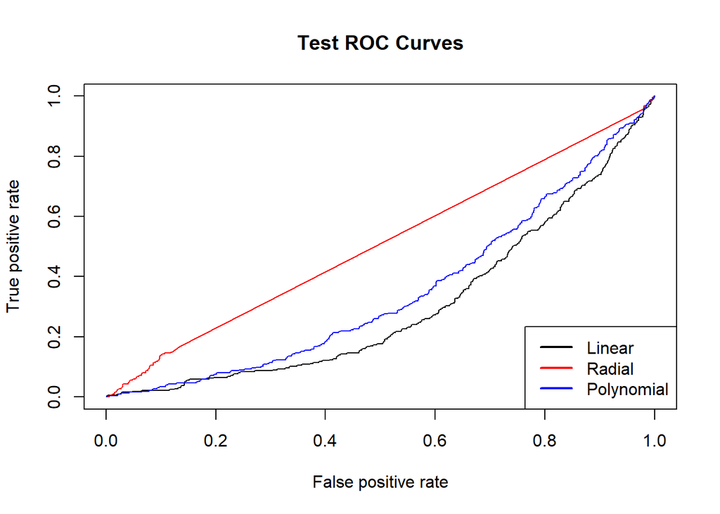

```r
fitted_linear_test <- attributes(predict(bestmod_linear, test_data, decision.values = TRUE))$decision.values
fitted_radial_test <- attributes(predict(bestmod_radial, test_data, decision.values = TRUE))$decision.values
fitted_poly_test <- attributes(predict(bestmod_poly, test_data, decision.values = TRUE))$decision.values

rocplot(-fitted_linear_test, test_data$CANCEREV, main = "Test ROC Curves")
rocplot(-fitted_radial_test, test_data$CANCEREV, add = TRUE, col = "red")
rocplot(-fitted_poly_test, test_data$CANCEREV, add = TRUE, col = "blue")
legend("bottomright", legend = c("Linear", "Radial", "Polynomial"),
       col = c("black", "red", "blue"), lwd = 2)
```

#### Lifestyle Cancer - Class Weight 1=1, 2=15

```r
set.seed(1)

df_cancer_life <- df_life %>%
  select(CANCEREV, HRSLEEP, MOD10DMIN, VIG10DMIN, HOURSWRK, ALCDAYSYR, CIGDAYMO) %>%
  filter(CANCEREV %in% c(1, 2)) %>%
  droplevels()

df_cancer_life_scaled <- df_cancer_life %>%
  mutate(across(where(is.numeric) & !matches("CANCEREV"), scale))

n <- nrow(df_cancer_life_scaled)
train <- sample(1:n, size = 0.7 * n)
train_data <- df_cancer_life_scaled[train, ]
test_data <- df_cancer_life_scaled[-train, ]
sub_train_data <- train_data[sample(1:nrow(train_data), 2000), ]

class_weights <- c("1" = 1, "2" = 15)

cat("\n--- Linear Kernel Results ---\n")
```

```
##
## --- Linear Kernel Results ---
```

```r
tune.out <- tune(svm, CANCEREV ~ ., data = sub_train_data, kernel = "linear",
    ranges = list(cost = c(0.1, 1, 10, 100)),
    class.weights = class_weights,
    max.iter = 10000)
summary(tune.out)
```

```
##
## Parameter tuning of 'svm':
##
## - sampling method: 10-fold cross validation
##
## - best parameters:
##  cost
##    10
##
## - best performance: 0.419
##
## - Detailed performance results:
##    cost  error dispersion
## 1   0.1 0.4215 0.01856670
## 2   1.0 0.4195 0.02020039
## 3  10.0 0.4190 0.01744834
## 4 100.0 0.4675 0.14275562
```

```r
best_cost_linear <- tune.out$best.parameters$cost
bestmod_linear <- svm(CANCEREV ~ ., data = train_data, kernel = "linear", cost = best_cost_linear, class.weights = class_weights,
                      max.iter = 10000, decision.values = TRUE)

ypred <- predict(bestmod_linear, train_data)
train_error <- 1 - mean(ypred == train_data$CANCEREV)
cat("Training error with optimal cost (Linear SVM): ", train_error, "\n")
```

```
## Training error with optimal cost (Linear SVM):  0.4541532
```

```r
print(table(predict = ypred, truth = train_data$CANCEREV))
```

```
##        truth
## predict    1    2
##       1 2916  168
##       2 2779  626
```

```r
ypred <- predict(bestmod_linear, test_data)
test_error <- 1 - mean(ypred == test_data$CANCEREV)
cat("\nTest error with optimal cost (Linear SVM): ", test_error, "\n")
```

```
##
## Test error with optimal cost (Linear SVM):  0.4694464
```

```r
print(table(predict = ypred, truth = test_data$CANCEREV))
```

```
##        truth
## predict    1    2
##       1 1242   61
##       2 1245  234
```

```r
cat("\n--- Radial Kernel Results ---\n")
```

```
##
## --- Radial Kernel Results ---
```

```r
tune.out <- tune(svm, CANCEREV ~ ., data = sub_train_data,
    kernel = "radial",
    ranges = list(
      cost = c(0.1, 1, 10, 100),
      gamma = c(10, 100, 1000, 10000)
    ),
    class.weights = class_weights)
summary(tune.out)
```

```
##
## Parameter tuning of 'svm':
##
## - sampling method: 10-fold cross validation
##
## - best parameters:
##  cost gamma
##   100 10000
##
## - best performance: 0.2015
##
## - Detailed performance results:
##     cost gamma  error dispersion
## 1    0.1    10 0.6470 0.03599383
## 2    1.0    10 0.3300 0.02666667
## 3   10.0    10 0.3155 0.02216729
## 4  100.0    10 0.2945 0.03278296
## 5    0.1   100 0.8030 0.04184628
## 6    1.0   100 0.2665 0.03504362
## 7   10.0   100 0.2510 0.03238655
## 8  100.0   100 0.2345 0.03570325
## 9    0.1  1000 0.8280 0.04042826
## 10   1.0  1000 0.2270 0.03489667
## 11  10.0  1000 0.2235 0.03771604
## 12 100.0  1000 0.2190 0.03893014
## 13   0.1 10000 0.8405 0.03854651
## 14   1.0 10000 0.2135 0.03391575
## 15  10.0 10000 0.2030 0.03449638
## 16 100.0 10000 0.2015 0.03283376
```

```r
best_cost_radial <- tune.out$best.parameters$cost
best_gamma_radial <- tune.out$best.parameters$gamma
bestmod_radial <- svm(CANCEREV ~ ., data = train_data, type = "C-classification", kernel = "radial",
               cost = best_cost_radial, gamma = best_gamma_radial, class.weights = class_weights, decision.values = TRUE)

ypred <- predict(bestmod_radial, train_data)
train_error <- 1 - mean(ypred == train_data$CANCEREV)
cat("Training error with optimal cost and gamma (Radial Kernel): ", train_error, "\n")
```

```
## Training error with optimal cost and gamma (Radial Kernel):  0.1833873
```

```r
print(table(predict = ypred, truth = train_data$CANCEREV))
```

```
##        truth
## predict    1    2
##       1 4507    2
##       2 1188  792
```

```r
ypred <- predict(bestmod_radial, test_data)
test_error <- 1 - mean(ypred == test_data$CANCEREV)
cat("\nTest error with optimal cost and gamma (Radial Kernel): ", test_error, "\n")
```

```
##
## Test error with optimal cost and gamma (Radial Kernel):  0.2774982
```

```r
print(table(predict = ypred, truth = test_data$CANCEREV))
```

```
##        truth
## predict    1    2
##       1 1893  178
##       2  594  117
```

```r
cat("\n--- Polynomial Kernel Results ---\n")
```

```
##
## --- Polynomial Kernel Results ---
```

```r
tune.out <- tune(svm, CANCEREV ~ ., data = sub_train_data,
    kernel = "polynomial",
    ranges = list(
      cost = c(1, 10, 100),
      degree = c(2, 3)
    ),
    class.weights = class_weights)
summary(tune.out)
```

```
##
## Parameter tuning of 'svm':
##
## - sampling method: 10-fold cross validation
##
## - best parameters:
##  cost degree
##   100      3
##
## - best performance: 0.6855
##
## - Detailed performance results:
##   cost degree  error dispersion
## 1    1      2 0.8610 0.02525426
## 2   10      2 0.8615 0.02494995
## 3  100      2 0.8635 0.02381060
## 4    1      3 0.7530 0.03614784
## 5   10      3 0.7200 0.04333333
## 6  100      3 0.6855 0.06175444
```

```r
best_cost_poly <- tune.out$best.parameters$cost
best_degree_poly <- tune.out$best.parameters$degree
bestmod_poly <- svm(CANCEREV ~ ., data = train_data, type = "C-classification", kernel = "polynomial",
               degree = best_degree_poly, coef0 = 1, cost = best_cost_poly, class.weights = class_weights, decision.values = TRUE)

ypred <- predict(bestmod_poly, train_data)
train_error <- 1 - mean(ypred == train_data$CANCEREV)
cat("Training error with optimal degree and cost (Polynomial Kernel): ", train_error, "\n")
```

```
## Training error with optimal degree and cost (Polynomial Kernel):  0.5470797
```

```r
print(table(predict = ypred, truth = train_data$CANCEREV))
```

```
##        truth
## predict    1    2
##       1 2251  106
##       2 3444  688
```

```r
ypred <- predict(bestmod_poly, test_data)
test_error <- 1 - mean(ypred == test_data$CANCEREV)
cat("\nTest error with optimal degree and cost (Polynomial Kernel): ", test_error, "\n")
```

```
##
## Test error with optimal degree and cost (Polynomial Kernel):  0.5560748
```

```r
print(table(predict = ypred, truth = test_data$CANCEREV))
```

```
##        truth
## predict    1    2
##       1  991   51
##       2 1496  244
```

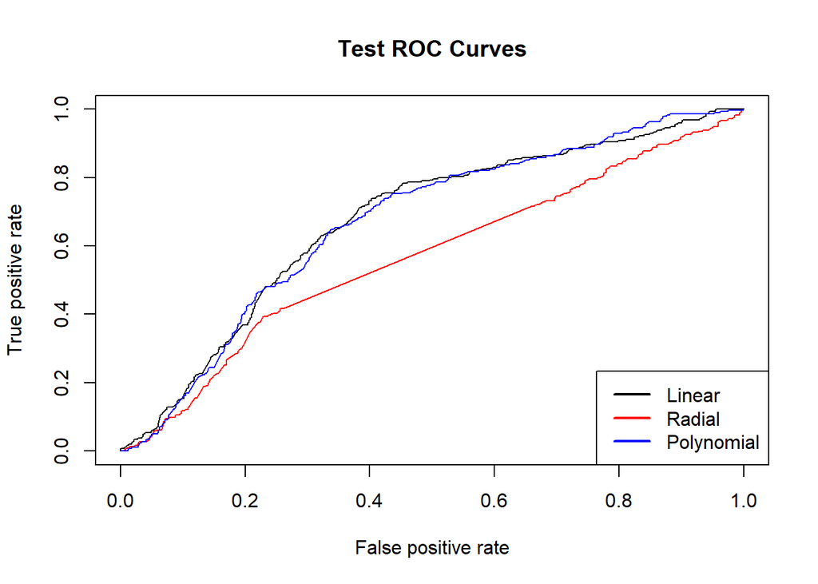

```r
fitted_linear_test <- attributes(predict(bestmod_linear, test_data, decision.values = TRUE))$decision.values
fitted_radial_test <- attributes(predict(bestmod_radial, test_data, decision.values = TRUE))$decision.values
fitted_poly_test <- attributes(predict(bestmod_poly, test_data, decision.values = TRUE))$decision.values

rocplot(-fitted_linear_test, test_data$CANCEREV, main = "Test ROC Curves")
rocplot(-fitted_radial_test, test_data$CANCEREV, add = TRUE, col = "red")
rocplot(-fitted_poly_test, test_data$CANCEREV, add = TRUE, col = "blue")
legend("bottomright", legend = c("Linear", "Radial", "Polynomial"),
       col = c("black", "red", "blue"), lwd = 2)
```

#### Eating Habits Cancer - Class Weight 1=1, 2=15

```r
set.seed(1)

df_cancer_food <- df_food %>%
  select(CANCEREV, FRUTNO, VEGENO, JUICEMNO, SALADSNO, BEANNO, SALSAMNO,
         TOMSAUCEMNO, SODAPNO, FRIESPNO, SPORDRMNO, FRTDRINKMNO,
         COFETEAMNO, POTATONO, PIZZANO) %>%
  filter(CANCEREV %in% c(1, 2)) %>%
  droplevels()

df_cancer_food_scaled <- df_cancer_food %>%
  mutate(across(where(is.numeric) & !matches("CANCEREV"), scale))

n <- nrow(df_cancer_food_scaled)
train <- sample(1:n, size = 0.7 * n)
train_data <- df_cancer_food_scaled[train, ]
test_data <- df_cancer_food_scaled[-train, ]
sub_train_data <- train_data[sample(1:nrow(train_data), 2000), ]

class_weights <- c("1" = 1, "2" = 15)

cat("\n--- Linear Kernel Results ---\n")
```

```
##
## --- Linear Kernel Results ---
```

```r
tune.out <- tune(svm, CANCEREV ~ ., data = sub_train_data, kernel = "linear",
    ranges = list(cost = c(0.1, 1, 10, 100)),
    class.weights = class_weights,
    max.iter = 100000)
summary(tune.out)
```

```
##
## Parameter tuning of 'svm':
##
## - sampling method: 10-fold cross validation
##
## - best parameters:
##  cost
##   0.1
##
## - best performance: 0.88
##
## - Detailed performance results:
##    cost error dispersion
## 1   0.1 0.880 0.02624669
## 2   1.0 0.880 0.02624669
## 3  10.0 0.880 0.02624669
## 4 100.0 0.882 0.02699794
```

```r
best_cost_linear <- tune.out$best.parameters$cost
bestmod_linear <- svm(CANCEREV ~ ., data = train_data, kernel = "linear", cost = best_cost_linear, class.weights = class_weights,
                      max.iter = 100000, decision.values = TRUE)

ypred <- predict(bestmod_linear, train_data)
train_error <- 1 - mean(ypred == train_data$CANCEREV)
cat("Training error with optimal cost (Linear SVM): ", train_error, "\n")
```

```
## Training error with optimal cost (Linear SVM):  0.8822986
```

```r
print(table(predict = ypred, truth = train_data$CANCEREV))
```

```
##        truth
## predict    1    2
##       1    0    0
##       2 5727  764
```

```r
ypred <- predict(bestmod_linear, test_data)
test_error <- 1 - mean(ypred == test_data$CANCEREV)
cat("\nTest error with optimal cost (Linear SVM): ", test_error, "\n")
```

```
##
## Test error with optimal cost (Linear SVM):  0.8828602
```

```r
print(table(predict = ypred, truth = test_data$CANCEREV))
```

```
##        truth
## predict    1    2
##       1    0    0
##       2 2457  326
```

```r
cat("\n--- Radial Kernel Results ---\n")
```

```
##
## --- Radial Kernel Results ---
```

```r
tune.out <- tune(svm, CANCEREV ~ ., data = sub_train_data,
    kernel = "radial",
    ranges = list(
      cost = c(0.1, 1, 10, 100),
      gamma = c(10, 100, 1000, 10000)
    ),
    class.weights = class_weights)
summary(tune.out)
```

```
##
## Parameter tuning of 'svm':
##
## - sampling method: 10-fold cross validation
##
## - best parameters:
##  cost gamma
##     1   100
##
## - best performance: 0.118
##
## - Detailed performance results:
##     cost gamma  error dispersion
## 1    0.1    10 0.8820 0.02750757
## 2    1.0    10 0.1205 0.02753281
## 3   10.0    10 0.1190 0.02695676
## 4  100.0    10 0.1190 0.02695676
## 5    0.1   100 0.8820 0.02750757
## 6    1.0   100 0.1180 0.02750757
## 7   10.0   100 0.1180 0.02750757
## 8  100.0   100 0.1180 0.02750757
## 9    0.1  1000 0.8820 0.02750757
## 10   1.0  1000 0.1180 0.02750757
## 11  10.0  1000 0.1180 0.02750757
## 12 100.0  1000 0.1180 0.02750757
## 13   0.1 10000 0.8820 0.02750757
## 14   1.0 10000 0.1180 0.02750757
## 15  10.0 10000 0.1180 0.02750757
## 16 100.0 10000 0.1180 0.02750757
```

```r
best_cost_radial <- tune.out$best.parameters$cost
best_gamma_radial <- tune.out$best.parameters$gamma
bestmod_radial <- svm(CANCEREV ~ ., data = train_data, type = "C-classification", kernel = "radial",
               cost = best_cost_radial, gamma = best_gamma_radial, class.weights = class_weights, decision.values = TRUE)

ypred <- predict(bestmod_radial, train_data)
train_error <- 1 - mean(ypred == train_data$CANCEREV)
cat("Training error with optimal cost and gamma (Radial Kernel): ", train_error, "\n")
```

```
## Training error with optimal cost and gamma (Radial Kernel):  0.001694654
```

```r
print(table(predict = ypred, truth = train_data$CANCEREV))
```

```
##        truth
## predict    1    2
##       1 5716    0
##       2   11  764
```

```r
ypred <- predict(bestmod_radial, test_data)
test_error <- 1 - mean(ypred == test_data$CANCEREV)
cat("\nTest error with optimal cost and gamma (Radial Kernel): ", test_error, "\n")
```

```
##
## Test error with optimal cost and gamma (Radial Kernel):  0.120733
```

```r
print(table(predict = ypred, truth = test_data$CANCEREV))
```

```
##        truth
## predict    1    2
##       1 2447  326
##       2   10    0
```

```r
cat("\n--- Polynomial Kernel Results ---\n")
```

```
##
## --- Polynomial Kernel Results ---
```

```r
tune.out <- tune(svm, CANCEREV ~ ., data = sub_train_data,
    kernel = "polynomial",
    ranges = list(
      cost = c(0.1, 1, 10, 100),
      degree = c(2, 3)
      ),
    class.weights = class_weights,
    max.iter = 100000)
summary(tune.out)
```

```
##
## Parameter tuning of 'svm':
##
## - sampling method: 10-fold cross validation
##
## - best parameters:
##  cost degree
##   100      3
##
## - best performance: 0.459
##
## - Detailed performance results:
##    cost degree  error dispersion
## 1   0.1      2 0.8280 0.02849951
## 2   1.0      2 0.7955 0.02929259
## 3  10.0      2 0.7680 0.03093003
## 4 100.0      2 0.7635 0.03249359
## 5   0.1      3 0.8055 0.02087662
## 6   1.0      3 0.7660 0.03034981
## 7  10.0      3 0.7080 0.03457681
## 8 100.0      3 0.4590 0.04706969
```

```r
best_cost_poly <- tune.out$best.parameters$cost
best_degree_poly <- tune.out$best.parameters$degree
bestmod_poly <- svm(CANCEREV ~ ., data = train_data, type = "C-classification", kernel = "polynomial",
               degree = best_degree_poly, coef0 = 1, cost = best_cost_poly, class.weights = class_weights, max.iter = 100000,
               decision.values = TRUE)

ypred <- predict(bestmod_poly, train_data)
train_error <- 1 - mean(ypred == train_data$CANCEREV)
cat("Training error with optimal degree and cost (Polynomial Kernel): ", train_error, "\n")
```

```
## Training error with optimal degree and cost (Polynomial Kernel):  0.5319673
```

```r
print(table(predict = ypred, truth = train_data$CANCEREV))
```

```
##        truth
## predict    1    2
##       1 2285   11
##       2 3442  753
```

```r
ypred <- predict(bestmod_poly, test_data)
test_error <- 1 - mean(ypred == test_data$CANCEREV)
cat("\nTest error with optimal degree and cost (Polynomial Kernel): ", test_error, "\n")
```

```
##
## Test error with optimal degree and cost (Polynomial Kernel):  0.609055
```

```r
print(table(predict = ypred, truth = test_data$CANCEREV))
```

```
##        truth
## predict    1    2
##       1  855   93
##       2 1602  233
```

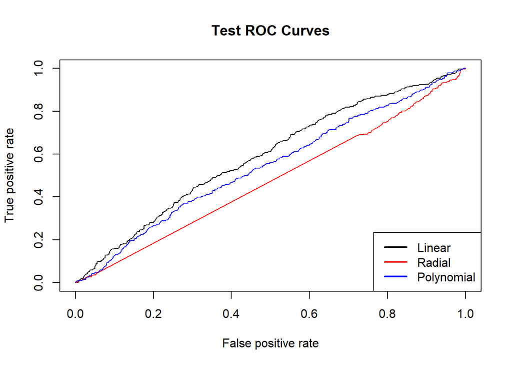

```r
fitted_linear_test <- attributes(predict(bestmod_linear, test_data, decision.values = TRUE))$decision.values
fitted_radial_test <- attributes(predict(bestmod_radial, test_data, decision.values = TRUE))$decision.values
fitted_poly_test <- attributes(predict(bestmod_poly, test_data, decision.values = TRUE))$decision.values

rocplot(-fitted_linear_test, test_data$CANCEREV, main = "Test ROC Curves")
rocplot(-fitted_radial_test, test_data$CANCEREV, add = TRUE, col = "red")
rocplot(-fitted_poly_test, test_data$CANCEREV, add = TRUE, col = "blue")
legend("bottomright", legend = c("Linear", "Radial", "Polynomial"),
       col = c("black", "red", "blue"), lwd = 2)
```

#### DIABETES DEMOGRAPHICS - Class weight 1=1, 2=15

```r
set.seed(1)

df_dia_dem <- df_dem %>%
  select(DIABETICEV, SEX, EDUC, HOURSWRK, POVERTY, HEIGHT, WEIGHT, BMICALC) %>%
  filter(DIABETICEV %in% c(1, 2)) %>%
  droplevels()

df_dia_dem_scaled <- df_dia_dem %>%
  mutate(across(where(is.numeric) & !matches("DIABETICEV"), scale))

n <- nrow(df_dia_dem_scaled)
train <- sample(1:n, size = 0.7 * n)
train_data <- df_dia_dem_scaled[train, ]
test_data <- df_dia_dem_scaled[-train, ]
sub_train_data <- train_data[sample(1:nrow(train_data), 2000), ]

class_weights <- c("1" = 1, "2" = 15)

cat("\n--- Linear Kernel Results ---\n")
```

```
##
## --- Linear Kernel Results ---
```

```r
tune.out <- tune(svm, DIABETICEV ~ ., data = sub_train_data, kernel = "linear",
    ranges = list(cost = c(1, 10, 100)),
    class.weights = class_weights)
summary(tune.out)
```

```
##
## Parameter tuning of 'svm':
##
## - sampling method: 10-fold cross validation
##
## - best parameters:
##  cost
##    10
##
## - best performance: 0.626
##
## - Detailed performance results:
##   cost  error dispersion
## 1    1 0.6330 0.07450578
## 2   10 0.6260 0.06927401
## 3  100 0.6265 0.07090878
```

```r
best_cost_linear <- tune.out$best.parameters$cost
bestmod_linear <- svm(DIABETICEV ~ ., data = train_data, kernel = "linear", cost = best_cost_linear, class.weights = class_weights, decision.values = TRUE)

ypred <- predict(bestmod_linear, train_data)
train_error <- 1 - mean(ypred == train_data$DIABETICEV)
cat("Training error with optimal cost (Linear SVM): ", round(train_error, 4), "\n")
```

```
## Training error with optimal cost (Linear SVM):  0.6459
```

```r
print(table(predict = ypred, truth = train_data$DIABETICEV))
```

```
##        truth
## predict    1    2
##       1 1519   60
##       2 3967  689
```

```r
ypred <- predict(bestmod_linear, test_data)
test_error <- 1 - mean(ypred == test_data$DIABETICEV)
cat("\nTest error with optimal cost (Linear SVM): ", round(test_error, 4), "\n")
```

```
##
## Test error with optimal cost (Linear SVM):  0.6554
```

```r
print(table(predict = ypred, truth = test_data$DIABETICEV))
```

```
##        truth
## predict    1    2
##       1  648   35
##       2 1717  273
```

```r
cat("\n--- Radial Kernel Results ---\n")
```

```
##
## --- Radial Kernel Results ---
```

```r
tune.out <- tune(svm, DIABETICEV ~ ., data = sub_train_data,
    kernel = "radial",
    ranges = list(
      cost = c(0.1, 1, 10, 100),
      gamma = c(10, 100, 1000, 10000)
    ),
    class.weights = class_weights)
summary(tune.out)
```

```
##
## Parameter tuning of 'svm':
##
## - sampling method: 10-fold cross validation
##
## - best parameters:
##  cost gamma
##     1  1000
##
## - best performance: 0.1245
##
## - Detailed performance results:
##     cost gamma  error dispersion
## 1    0.1    10 0.8735 0.02698250
## 2    1.0    10 0.1305 0.02639971
## 3   10.0    10 0.1295 0.02681728
## 4  100.0    10 0.1295 0.02681728
## 5    0.1   100 0.8755 0.02671350
## 6    1.0   100 0.1260 0.02796824
## 7   10.0   100 0.1260 0.02796824
## 8  100.0   100 0.1260 0.02796824
## 9    0.1  1000 0.8755 0.02671350
## 10   1.0  1000 0.1245 0.02803272
## 11  10.0  1000 0.1245 0.02803272
## 12 100.0  1000 0.1245 0.02803272
## 13   0.1 10000 0.8755 0.02671350
## 14   1.0 10000 0.1245 0.02803272
## 15  10.0 10000 0.1245 0.02803272
## 16 100.0 10000 0.1245 0.02803272
```

```r
best_cost_radial <- tune.out$best.parameters$cost
best_gamma_radial <- tune.out$best.parameters$gamma
bestmod_radial <- svm(DIABETICEV ~ ., data = train_data, type = "C-classification", kernel = "radial",
               cost = best_cost_radial, gamma = best_gamma_radial, class.weights = class_weights, decision.values = TRUE)

ypred <- predict(bestmod_radial, train_data)
train_error <- 1 - mean(ypred == train_data$DIABETICEV)
cat("Training error with optimal cost and gamma (Radial Kernel): ", round(train_error, 4), "\n")
```

```
## Training error with optimal cost and gamma (Radial Kernel):  0.0037
```

```r
print(table(predict = ypred, truth = train_data$DIABETICEV))
```

```
##        truth
## predict    1    2
##       1 5463    0
##       2   23  749
```

```r
ypred <- predict(bestmod_radial, test_data)
test_error <- 1 - mean(ypred == test_data$DIABETICEV)
cat("\nTest error with optimal cost and gamma (Radial Kernel): ", round(test_error, 4), "\n")
```

```
##
## Test error with optimal cost and gamma (Radial Kernel):  0.1156
```

```r
print(table(predict = ypred, truth = test_data$DIABETICEV))
```

```
##        truth
## predict    1    2
##       1 2362  306
##       2    3    2
```

```r
cat("\n--- Polynomial Kernel Results ---\n")
```

```
##
## --- Polynomial Kernel Results ---
```

```r
tune.out <- tune(svm, DIABETICEV ~ ., data = sub_train_data,
    kernel = "polynomial",
    ranges = list(
      cost = c(1, 10, 100),
      degree = c(2, 3)
    ),
    class.weights = class_weights)
summary(tune.out)
```

```
##
## Parameter tuning of 'svm':
##
## - sampling method: 10-fold cross validation
##
## - best parameters:
##  cost degree
##   100      3
##
## - best performance: 0.4105
##
## - Detailed performance results:
##   cost degree  error dispersion
## 1    1      2 0.6995 0.03312015
## 2   10      2 0.5460 0.03098387
## 3  100      2 0.4455 0.03692711
## 4    1      3 0.8715 0.01986762
## 5   10      3 0.6680 0.03757955
## 6  100      3 0.4105 0.02852387
```

```r
best_cost_poly <- tune.out$best.parameters$cost
best_degree_poly <- tune.out$best.parameters$degree
bestmod_poly <- svm(DIABETICEV ~ ., data = train_data, type = "C-classification", kernel = "polynomial",
               degree = best_degree_poly, coef0 = 1, cost = best_cost_poly, class.weights = class_weights, decision.values = TRUE)

ypred <- predict(bestmod_poly, train_data)
train_error <- 1 - mean(ypred == train_data$DIABETICEV)
cat("Training error with optimal degree and cost (Polynomial Kernel): ", round(train_error, 4), "\n")
```

```
## Training error with optimal degree and cost (Polynomial Kernel):  0.435
```

```r
print(table(predict = ypred, truth = train_data$DIABETICEV))
```

```
##        truth
## predict    1    2
##       1 2806   32
##       2 2680  717
```

```r
ypred <- predict(bestmod_poly, test_data)
test_error <- 1 - mean(ypred == test_data$DIABETICEV)
cat("\nTest error with optimal degree and cost (Polynomial Kernel): ", round(test_error, 4), "\n")
```

```
##
## Test error with optimal degree and cost (Polynomial Kernel):  0.4942
```

```r
print(table(predict = ypred, truth = test_data$DIABETICEV))
```

```
##        truth
## predict    1    2
##       1 1138   94
##       2 1227  214
```

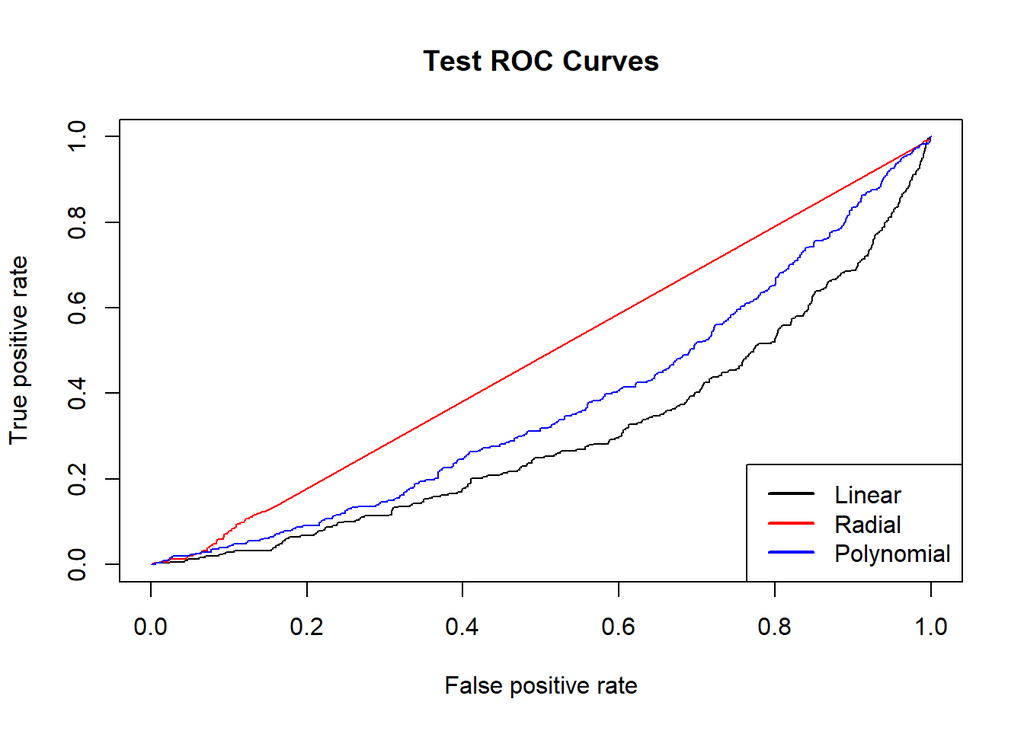

```r
fitted_linear_test <- attributes(predict(bestmod_linear, test_data, decision.values = TRUE))$decision.values
fitted_radial_test <- attributes(predict(bestmod_radial, test_data, decision.values = TRUE))$decision.values
fitted_poly_test <- attributes(predict(bestmod_poly, test_data, decision.values = TRUE))$decision.values

rocplot(-fitted_linear_test, test_data$DIABETICEV, main = "Test ROC Curves")
rocplot(-fitted_radial_test, test_data$DIABETICEV, add = TRUE, col = "red")
rocplot(-fitted_poly_test, test_data$DIABETICEV, add = TRUE, col = "blue")
legend("bottomright", legend = c("Linear", "Radial", "Polynomial"),
       col = c("black", "red", "blue"), lwd = 2)
```

#### LIFESTYLE DIABETES - Class Weight 1=1, 2=15

```r
set.seed(1)

df_dia_life <- df_life %>%
  select(DIABETICEV, HRSLEEP, MOD10DMIN, VIG10DMIN, HOURSWRK, ALCDAYSYR, CIGDAYMO) %>%
  filter(DIABETICEV %in% c(1, 2)) %>%
  droplevels()

df_dia_life_scaled <- df_dia_life %>%
  mutate(across(where(is.numeric) & !matches("DIABETICEV"), scale))

n <- nrow(df_dia_life_scaled)
train <- sample(1:n, size = 0.7 * n)
train_data <- df_dia_life_scaled[train, ]
test_data <- df_dia_life_scaled[-train, ]
sub_train_data <- train_data[sample(1:nrow(train_data), 2000), ]

class_weights <- c("1" = 1, "2" = 15)

cat("\n--- Linear Kernel Results ---\n")
```

```
##
## --- Linear Kernel Results ---
```

```r
tune.out <- tune(svm, DIABETICEV ~ ., data = sub_train_data, kernel = "linear",
    ranges = list(cost = c(1, 10, 100)),
    class.weights = class_weights)
summary(tune.out)
```

```
##
## Parameter tuning of 'svm':
##
## - sampling method: 10-fold cross validation
##
## - best parameters:
##  cost
##     1
##
## - best performance: 0.844
##
## - Detailed performance results:
##   cost  error dispersion
## 1    1 0.8440 0.05767726
## 2   10 0.8445 0.05629535
## 3  100 0.8585 0.02809211
```

```r
best_cost_linear <- tune.out$best.parameters$cost
bestmod_linear <- svm(DIABETICEV ~ ., data = train_data, kernel = "linear", cost = best_cost_linear, class.weights = class_weights, decision.values = TRUE)

ypred <- predict(bestmod_linear, train_data)
train_error <- 1 - mean(ypred == train_data$DIABETICEV)
cat("Training error with optimal cost (Linear SVM): ", train_error, "\n")
```

```
## Training error with optimal cost (Linear SVM):  0.8728618
```

```r
print(table(predict = ypred, truth = train_data$DIABETICEV))
```

```
##        truth
## predict    1    2
##       1    0    0
##       2 5664  825
```

```r
ypred <- predict(bestmod_linear, test_data)
test_error <- 1 - mean(ypred == test_data$DIABETICEV)
cat("\nTest error with optimal cost (Linear SVM): ", test_error, "\n")
```

```
##
## Test error with optimal cost (Linear SVM):  0.8888889
```

```r
print(table(predict = ypred, truth = test_data$DIABETICEV))
```

```
##        truth
## predict    1    2
##       1    0    0
##       2 2472  309
```

```r
cat("\n--- Radial Kernel Results ---\n")
```

```
##
## --- Radial Kernel Results ---
```

```r
tune.out <- tune(svm, DIABETICEV ~ ., data = sub_train_data,
    kernel = "radial",
    ranges = list(
      cost = c(0.1, 1, 10, 100),
      gamma = c(10, 100, 1000, 10000)
    ),
    class.weights = class_weights)
summary(tune.out)
```

```
##
## Parameter tuning of 'svm':
##
## - sampling method: 10-fold cross validation
##
## - best parameters:
##  cost gamma
##   100 10000
##
## - best performance: 0.2035
##
## - Detailed performance results:
##     cost gamma  error dispersion
## 1    0.1    10 0.6300 0.04075673
## 2    1.0    10 0.2890 0.04724640
## 3   10.0    10 0.2720 0.04522782
## 4  100.0    10 0.2610 0.04351245
## 5    0.1   100 0.7645 0.03235652
## 6    1.0   100 0.2440 0.03710346
## 7   10.0   100 0.2405 0.03774549
## 8  100.0   100 0.2330 0.03938415
## 9    0.1  1000 0.7990 0.03306559
## 10   1.0  1000 0.2305 0.04186287
## 11  10.0  1000 0.2235 0.04320815
## 12 100.0  1000 0.2135 0.03916135
## 13   0.1 10000 0.8130 0.03128720
## 14   1.0 10000 0.2095 0.03654905
## 15  10.0 10000 0.2040 0.03665151
## 16 100.0 10000 0.2035 0.03742029
```

```r
best_cost_radial <- tune.out$best.parameters$cost
best_gamma_radial <- tune.out$best.parameters$gamma
bestmod_radial <- svm(DIABETICEV ~ ., data = train_data, type = "C-classification", kernel = "radial",
               cost = best_cost_radial, gamma = best_gamma_radial, class.weights = class_weights, decision.values = TRUE)

ypred <- predict(bestmod_radial, train_data)
train_error <- 1 - mean(ypred == train_data$DIABETICEV)
cat("Training error with optimal cost and gamma (Radial Kernel): ", train_error, "\n")
```

```
## Training error with optimal cost and gamma (Radial Kernel):  0.1967946
```

```r
print(table(predict = ypred, truth = train_data$DIABETICEV))
```

```
##        truth
## predict    1    2
##       1 4388    1
##       2 1276  824
```

```r
ypred <- predict(bestmod_radial, test_data)
test_error <- 1 - mean(ypred == test_data$DIABETICEV)
cat("\nTest error with optimal cost and gamma (Radial Kernel): ", test_error, "\n")
```

```
##
## Test error with optimal cost and gamma (Radial Kernel):  0.2815534
```

```r
print(table(predict = ypred, truth = test_data$DIABETICEV))
```

```
##        truth
## predict    1    2
##       1 1860  171
##       2  612  138
```

```r
cat("\n--- Polynomial Kernel Results ---\n")
```

```
##
## --- Polynomial Kernel Results ---
```

```r
tune.out <- tune(svm, DIABETICEV ~ ., data = sub_train_data,
    kernel = "polynomial",
    ranges = list(
      cost = c(1, 10, 100),
      degree = c(2, 3)
    ),
    class.weights = class_weights)
summary(tune.out)
```

```
##
## Parameter tuning of 'svm':
##
## - sampling method: 10-fold cross validation
##
## - best parameters:
##  cost degree
##   100      3
##
## - best performance: 0.5795
##
## - Detailed performance results:
##   cost degree  error dispersion
## 1    1      2 0.8485 0.03300253
## 2   10      2 0.8425 0.03335416
## 3  100      2 0.8405 0.03578097
## 4    1      3 0.7825 0.04685972
## 5   10      3 0.7190 0.03604010
## 6  100      3 0.5795 0.03847438
```

```r
best_cost_poly <- tune.out$best.parameters$cost
best_degree_poly <- tune.out$best.parameters$degree
bestmod_poly <- svm(DIABETICEV ~ ., data = train_data, type = "C-classification", kernel = "polynomial",
               degree = best_degree_poly, coef0 = 1, cost = best_cost_poly, class.weights = class_weights, decision.values = TRUE)

ypred <- predict(bestmod_poly, train_data)
train_error <- 1 - mean(ypred == train_data$DIABETICEV)
cat("Training error with optimal degree and cost (Polynomial Kernel): ", train_error, "\n")
```

```
## Training error with optimal degree and cost (Polynomial Kernel):  0.6433965
```

```r
print(table(predict = ypred, truth = train_data$DIABETICEV))
```

```
##        truth
## predict    1    2
##       1 1536   47
##       2 4128  778
```

```r
ypred <- predict(bestmod_poly, test_data)
test_error <- 1 - mean(ypred == test_data$DIABETICEV)
cat("\nTest error with optimal degree and cost (Polynomial Kernel): ", test_error, "\n")
```

```
##
## Test error with optimal degree and cost (Polynomial Kernel):  0.6720604
```

```r
print(table(predict = ypred, truth = test_data$DIABETICEV))
```

```
##        truth
## predict    1    2
##       1  641   38
##       2 1831  271
```

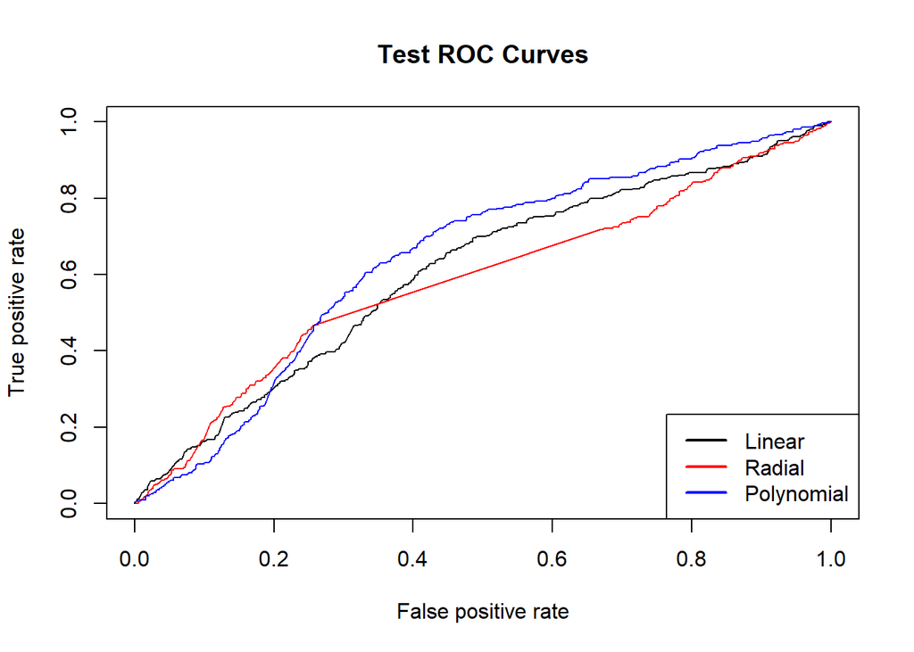

```r
fitted_linear_test <- attributes(predict(bestmod_linear, test_data, decision.values = TRUE))$decision.values
fitted_radial_test <- attributes(predict(bestmod_radial, test_data, decision.values = TRUE))$decision.values
fitted_poly_test <- attributes(predict(bestmod_poly, test_data, decision.values = TRUE))$decision.values

rocplot(-fitted_linear_test, test_data$DIABETICEV, main = "Test ROC Curves")
rocplot(-fitted_radial_test, test_data$DIABETICEV, add = TRUE, col = "red")
rocplot(-fitted_poly_test, test_data$DIABETICEV, add = TRUE, col = "blue")
legend("bottomright", legend = c("Linear", "Radial", "Polynomial"),
       col = c("black", "red", "blue"), lwd = 2)
```

#### Food DIABETES - Class Weight 1=1, 2=15

```r
set.seed(1)

df_dia_food <- df_food %>%
  select(DIABETICEV, FRUTNO, VEGENO, JUICEMNO, SALADSNO, BEANNO, SALSAMNO,
         TOMSAUCEMNO, SODAPNO, FRIESPNO, SPORDRMNO, FRTDRINKMNO,
         COFETEAMNO, POTATONO, PIZZANO) %>%
  filter(DIABETICEV %in% c(1, 2)) %>%
  droplevels()

df_dia_food_scaled <- df_dia_food %>%
  mutate(across(where(is.numeric) & !matches("DIABETICEV"), scale))

n <- nrow(df_dia_food_scaled)
train <- sample(1:n, size = 0.7 * n)
train_data <- df_dia_food_scaled[train, ]
test_data <- df_dia_food_scaled[-train, ]
sub_train_data <- train_data[sample(1:nrow(train_data), 2000), ]

class_weights <- c("1" = 1, "2" = 15)

cat("\n--- Linear Kernel Results ---\n")
```

```
##
## --- Linear Kernel Results ---
```

```r
tune.out <- tune(svm, DIABETICEV ~ ., data = sub_train_data, kernel = "linear",
    ranges = list(cost = c(1, 10, 100)),
    class.weights = class_weights)
summary(tune.out)
```

```
##
## Parameter tuning of 'svm':
##
## - sampling method: 10-fold cross validation
##
## - best parameters:
##  cost
##     1
##
## - best performance: 0.881
##
## - Detailed performance results:
##   cost error dispersion
## 1    1 0.881 0.01969207
## 2   10 0.881 0.01969207
## 3  100 0.885 0.01885618
```

```r
best_cost_linear <- tune.out$best.parameters$cost
bestmod_linear <- svm(DIABETICEV ~ ., data = train_data, kernel = "linear", cost = best_cost_linear, class.weights = class_weights, decision.values = TRUE)

ypred <- predict(bestmod_linear, train_data)
train_error <- 1 - mean(ypred == train_data$DIABETICEV)
cat("Training error with optimal cost (Linear SVM): ", train_error, "\n")
```

```
## Training error with optimal cost (Linear SVM):  0.8773687
```

```r
print(table(predict = ypred, truth = train_data$DIABETICEV))
```

```
##        truth
## predict    1    2
##       1    0    0
##       2 5695  796
```

```r
ypred <- predict(bestmod_linear, test_data)
test_error <- 1 - mean(ypred == test_data$DIABETICEV)
cat("\nTest error with optimal cost (Linear SVM): ", test_error, "\n")
```

```
##
## Test error with optimal cost (Linear SVM):  0.879267
```

```r
print(table(predict = ypred, truth = test_data$DIABETICEV))
```

```
##        truth
## predict    1    2
##       1    0    0
##       2 2447  336
```

```r
cat("\n--- Radial Kernel Results ---\n")
```

```
##
## --- Radial Kernel Results ---
```

```r
tune.out <- tune(svm, DIABETICEV ~ ., data = sub_train_data,
    kernel = "radial",
    ranges = list(
      cost = c(0.1, 1, 10, 100),
      gamma = c(10, 100, 1000, 10000)
    ),
    class.weights = class_weights)
summary(tune.out)
```

```
##
## Parameter tuning of 'svm':
##
## - sampling method: 10-fold cross validation
##
## - best parameters:
##  cost gamma
##     1    10
##
## - best performance: 0.115
##
## - Detailed performance results:
##     cost gamma error dispersion
## 1    0.1    10 0.880 0.02905933
## 2    1.0    10 0.115 0.02758824
## 3   10.0    10 0.115 0.02758824
## 4  100.0    10 0.115 0.02758824
## 5    0.1   100 0.885 0.02758824
## 6    1.0   100 0.115 0.02758824
## 7   10.0   100 0.115 0.02758824
## 8  100.0   100 0.115 0.02758824
## 9    0.1  1000 0.885 0.02758824
## 10   1.0  1000 0.115 0.02758824
## 11  10.0  1000 0.115 0.02758824
## 12 100.0  1000 0.115 0.02758824
## 13   0.1 10000 0.885 0.02758824
## 14   1.0 10000 0.115 0.02758824
## 15  10.0 10000 0.115 0.02758824
## 16 100.0 10000 0.115 0.02758824
```

```r
best_cost_radial <- tune.out$best.parameters$cost
best_gamma_radial <- tune.out$best.parameters$gamma
bestmod_radial <- svm(DIABETICEV ~ ., data = train_data, type = "C-classification", kernel = "radial",
               cost = best_cost_radial, gamma = best_gamma_radial, class.weights = class_weights, decision.values = TRUE)

ypred <- predict(bestmod_radial, train_data)
train_error <- 1 - mean(ypred == train_data$DIABETICEV)
cat("Training error with optimal cost and gamma (Radial Kernel): ", train_error, "\n")
```

```
## Training error with optimal cost and gamma (Radial Kernel):  0.003389308
```

```r
print(table(predict = ypred, truth = train_data$DIABETICEV))
```

```
##        truth
## predict    1    2
##       1 5673    0
##       2   22  796
```

```r
ypred <- predict(bestmod_radial, test_data)
test_error <- 1 - mean(ypred == test_data$DIABETICEV)
cat("\nTest error with optimal cost and gamma (Radial Kernel): ", test_error, "\n")
```

```
##
## Test error with optimal cost and gamma (Radial Kernel):  0.1282788
```

```r
print(table(predict = ypred, truth = test_data$DIABETICEV))
```

```
##        truth
## predict    1    2
##       1 2422  332
##       2   25    4
```

```r
cat("\n--- Polynomial Kernel Results ---\n")
```

```
##
## --- Polynomial Kernel Results ---
```

```r
tune.out <- tune(svm, DIABETICEV ~ ., data = sub_train_data,
    kernel = "polynomial",
    ranges = list(
      cost = c(1, 10, 100),
      degree = c(2, 3)
    ),
    class.weights = class_weights)
summary(tune.out)
```

```
##
## Parameter tuning of 'svm':
##
## - sampling method: 10-fold cross validation
##
## - best parameters:
##  cost degree
##   100      3
##
## - best performance: 0.494
##
## - Detailed performance results:
##   cost degree  error dispersion
## 1    1      2 0.7785 0.03742029
## 2   10      2 0.7225 0.04404858
## 3  100      2 0.6920 0.05067325
## 4    1      3 0.7645 0.03122054
## 5   10      3 0.6975 0.03889087
## 6  100      3 0.4940 0.05065131
```

```r
best_cost_poly <- tune.out$best.parameters$cost
best_degree_poly <- tune.out$best.parameters$degree
bestmod_poly <- svm(DIABETICEV ~ ., data = train_data, type = "C-classification", kernel = "polynomial",
               degree = best_degree_poly, coef0 = 1, cost = best_cost_poly, class.weights = class_weights, decision.values = TRUE)

ypred <- predict(bestmod_poly, train_data)
train_error <- 1 - mean(ypred == train_data$DIABETICEV)
cat("Training error with optimal degree and cost (Polynomial Kernel): ", train_error, "\n")
```

```
## Training error with optimal degree and cost (Polynomial Kernel):  0.5575412
```

```r
print(table(predict = ypred, truth = train_data$DIABETICEV))
```

```
##        truth
## predict    1    2
##       1 2083    7
##       2 3612  789
```

```r
ypred <- predict(bestmod_poly, test_data)
test_error <- 1 - mean(ypred == test_data$DIABETICEV)
cat("\nTest error with optimal degree and cost (Polynomial Kernel): ", test_error, "\n")
```

```
##
## Test error with optimal degree and cost (Polynomial Kernel):  0.6263026
```

```r
print(table(predict = ypred, truth = test_data$DIABETICEV))
```

```
##        truth
## predict    1    2
##       1  780   76
##       2 1667  260
```

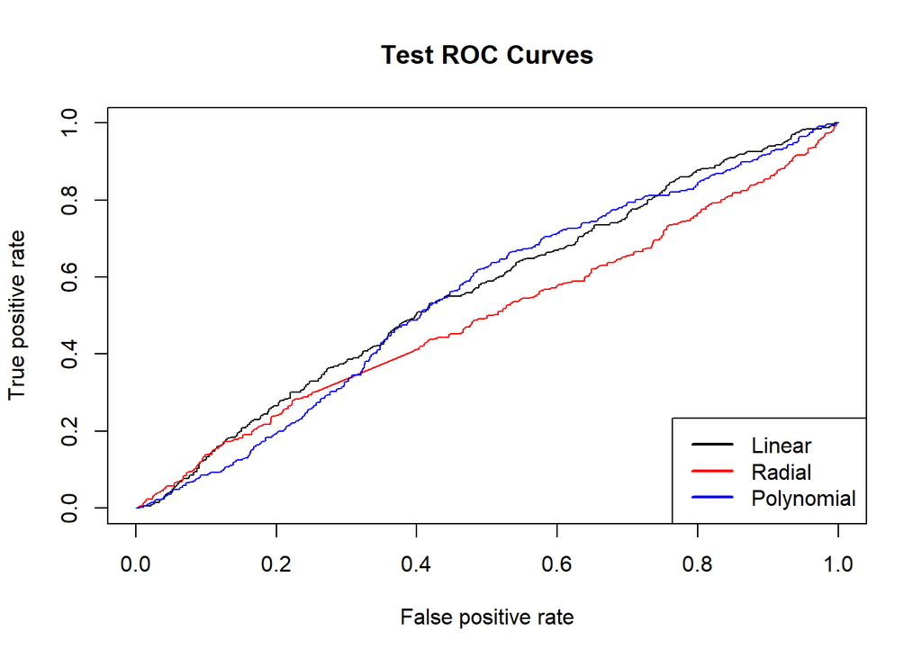

```r
fitted_linear_test <- attributes(predict(bestmod_linear, test_data, decision.values = TRUE))$decision.values
fitted_radial_test <- attributes(predict(bestmod_radial, test_data, decision.values = TRUE))$decision.values
fitted_poly_test <- attributes(predict(bestmod_poly, test_data, decision.values = TRUE))$decision.values

rocplot(-fitted_linear_test, test_data$DIABETICEV, main = "Test ROC Curves")
rocplot(-fitted_radial_test, test_data$DIABETICEV, add = TRUE, col = "red")
rocplot(-fitted_poly_test, test_data$DIABETICEV, add = TRUE, col = "blue")
legend("bottomright", legend = c("Linear", "Radial", "Polynomial"),
       col = c("black", "red", "blue"), lwd = 2)
```